# The truth behind the lyrics

## Author: Jinxu Xiang

This report is prepared with the following environmental settings.

```r
print(R.version)
```

```
##                _
## platform       x86_64-w64-mingw32
## arch           x86_64
## os             mingw32
## system         x86_64, mingw32
## status
## major          3
## minor          6.2
## year           2019
## month          12
## day            12
## svn rev        77560
## language       R
## version.string R version 3.6.2 (2019-12-12)
## nickname       Dark and Stormy Night
```

First,I processed the raw textual data ‘lyrics.RData’ saved in ‘data’ file by cleaning data, removing stopwords and creating a tidy version of texts which is saved in ‘output’ file.

Then,I combined the processed text with artist information ‘artists.csv’ and saved the joint data in ‘output’ file. The ‘Origin’ column of joint data contains the name of city and country (or state in America). So I extracted the names of each reigon and saved it as ‘Precessed_country’.

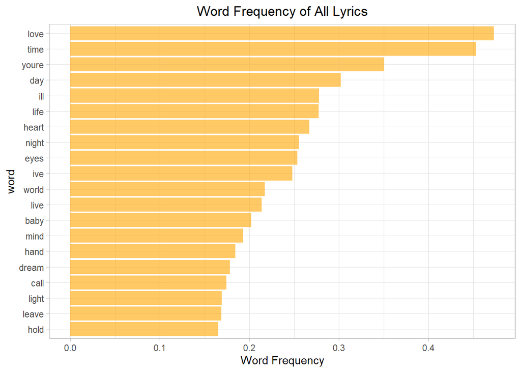

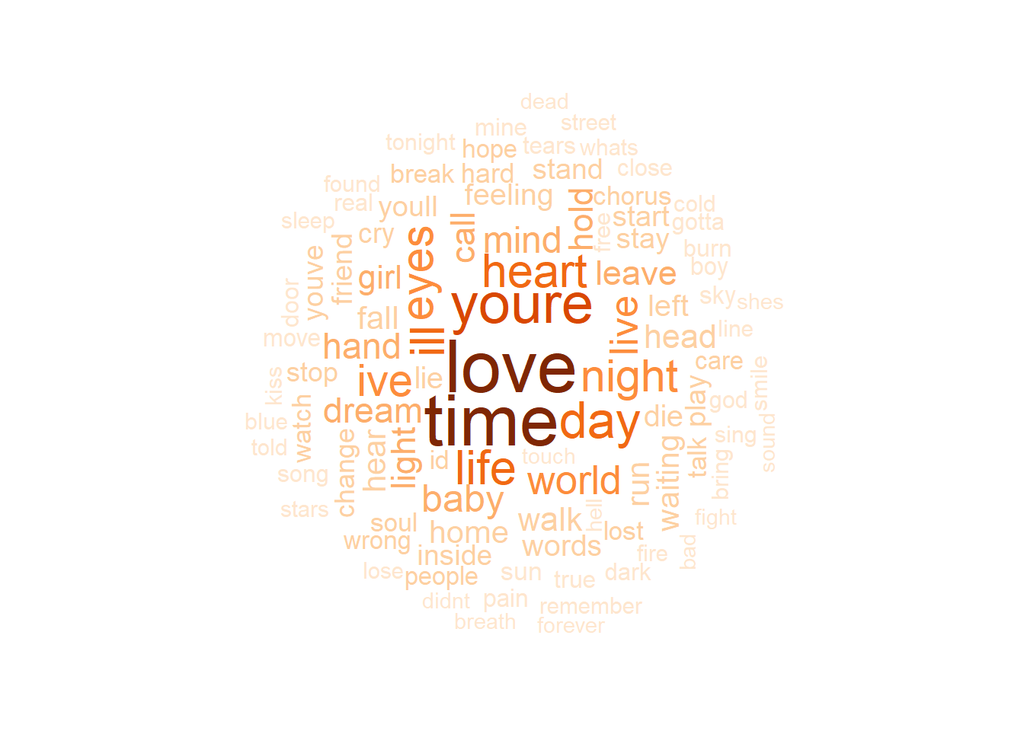

This is the wordcloud of all lyrics. As you can see, the word ‘love’, ‘light’, ‘heartlife’, ‘dream’ etc. appear many times. Most of words in this graph are positive. However, words like ‘ill’, ‘die’ and ‘cry’ also appear frenquently. But compared to the previous words, the number and frequency of negative words are significantly lower. Although at this time we will think that most music is positive, is it true that most of music is positive?

### Question 1 - Is it true that most of music is positive?

To quickly find answers, first I made a dynamic shinyapp to search keywords under different condition. I designed the drop-down tab to select different genres and regions, and the slider to select the year interval. If you want to select all genres or regions, you can select ‘All genres’ or ‘All Region’. However, this cannot be displayed after being stored as html, so I put it in ‘Project1-shinyapp’ in ‘doc’ file.

After using shinyapp to control variables, I have a preliminary understanding of the question I want to do. Next I use dataset ‘bing’ (from Bing Liu and collaborators, https://www.cs.uic.edu/~liub/FBS/sentiment-analysis.html) to distinguish positive and negative words.

First,I gave positive and negative words +1 score and -1 score respectively. Then, I scored and summed all stemmed words in each piece of lyrics. For the total score obtained, if the total score is positive, it will be classified as positive music, and if the total score is negative, it will be classified as negative music. I used two scoring methods. The first one counts the repeated words in each stemmed lyrics, and the second one counts the repeated words only once in each stemmed lyrics. The two types of score statistics are as follows.

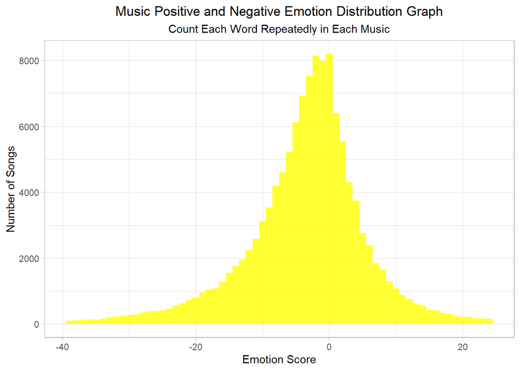

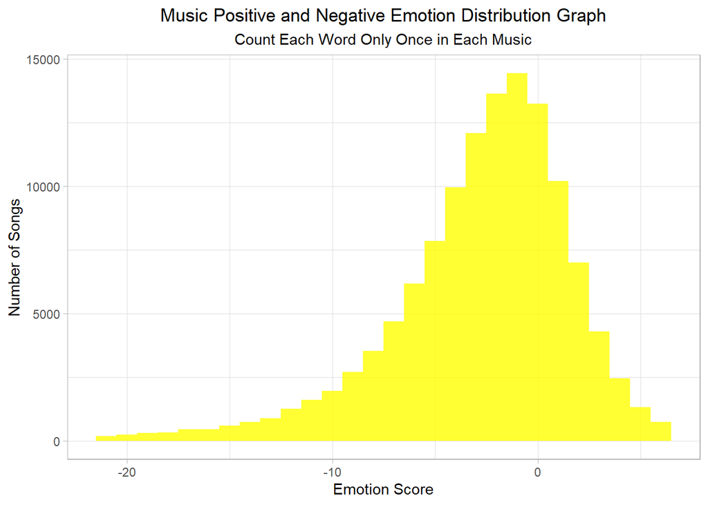

These two graphs above are the opposite of what I said before. Even though positive words occupy most of the wordcloud, about 70% music use more negative words. In addition, the emotion score which each word only count once looks like Poisson distribution. This property may be used in more places.

The statistical model of this data is too good, it is difficult to imagine that the 120,000 data can get a distribution that looks a lot like the real distribution. In addition, considering that there are many strange author names, song names and lyrics in this dataset, it will increase people’s doubt about the reality of this dataset.

Since more negative words are shown below the appearance of positive words, so where, when and what kind of music use negative words more? Where, when and what kind of music use positive words more? The following graphs make statistics of different categories of lyrics.

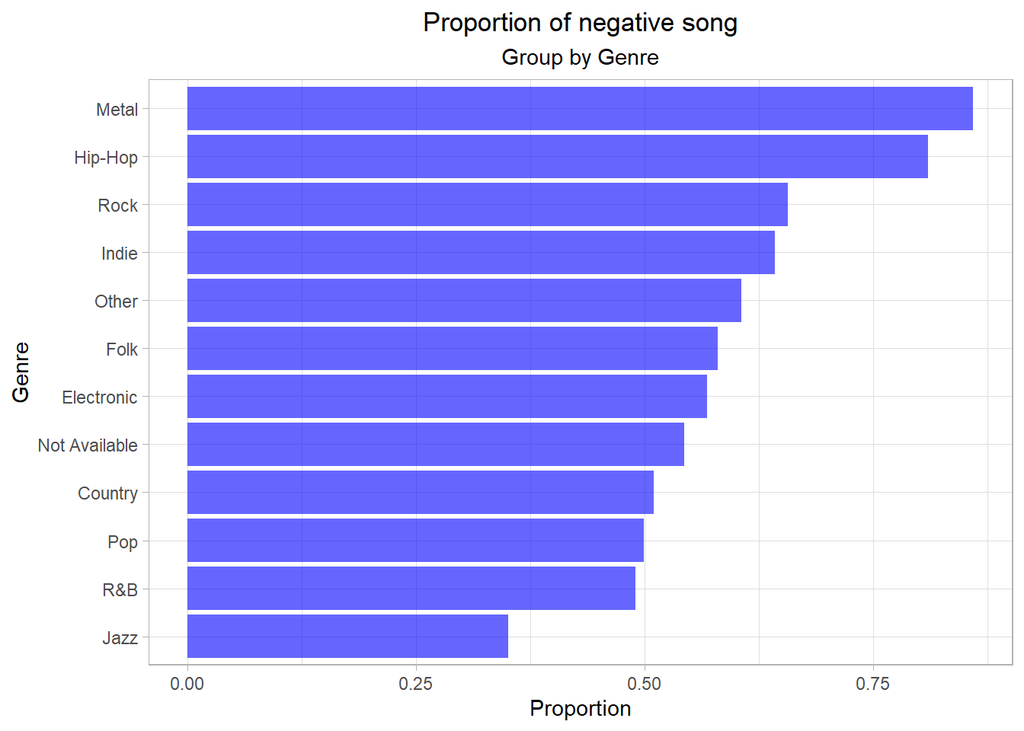

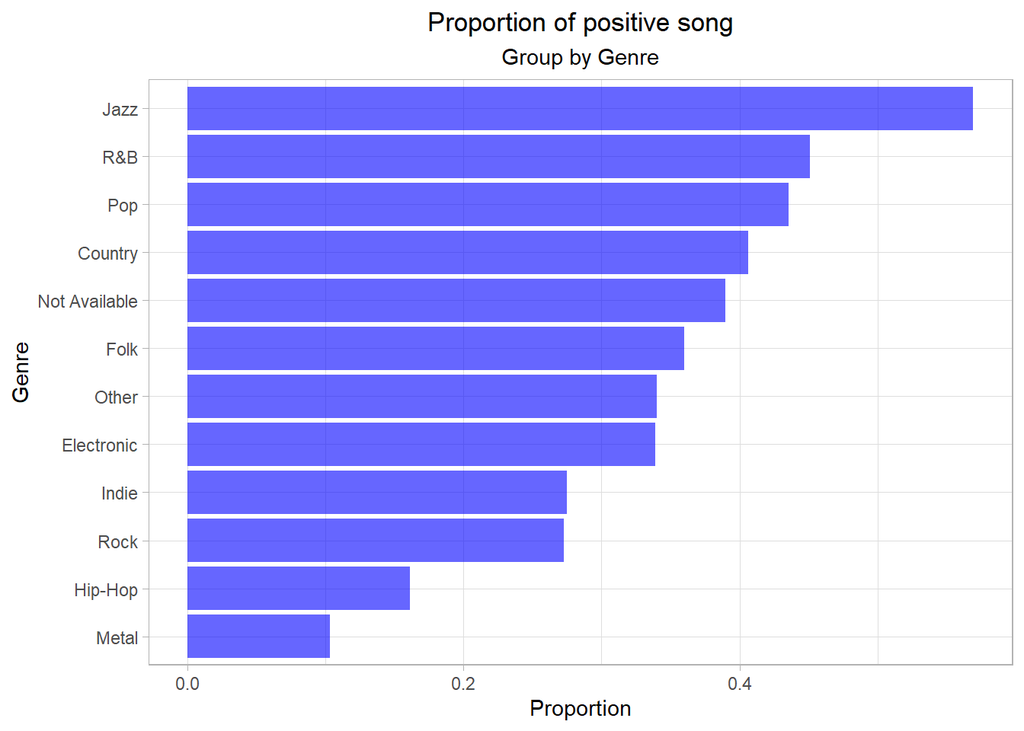

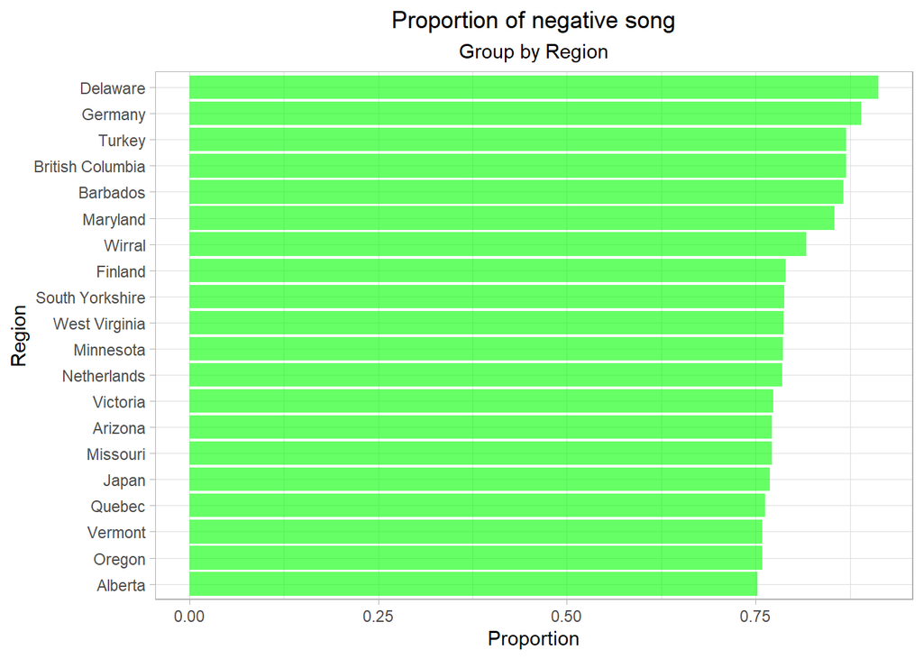

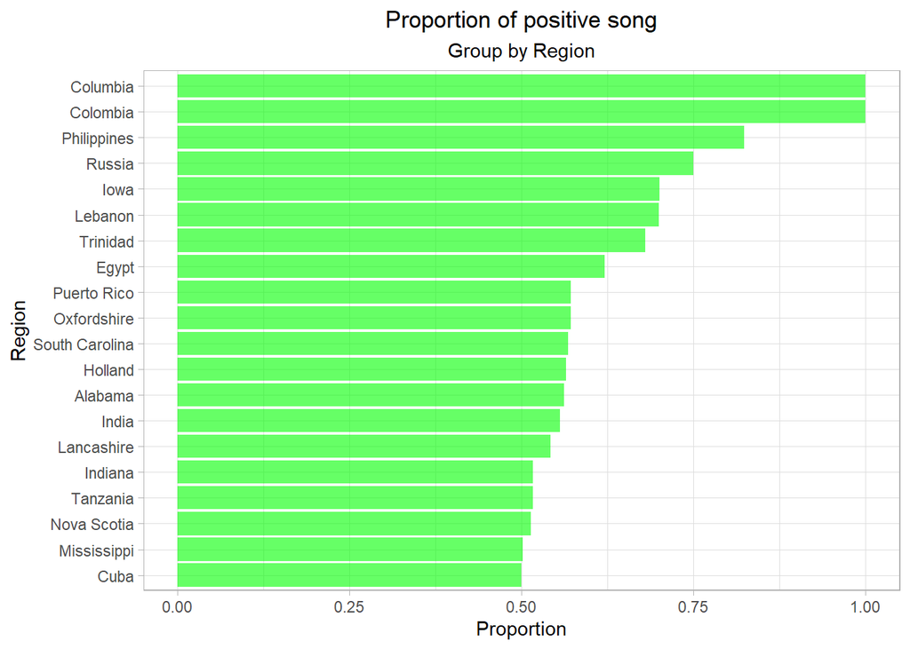

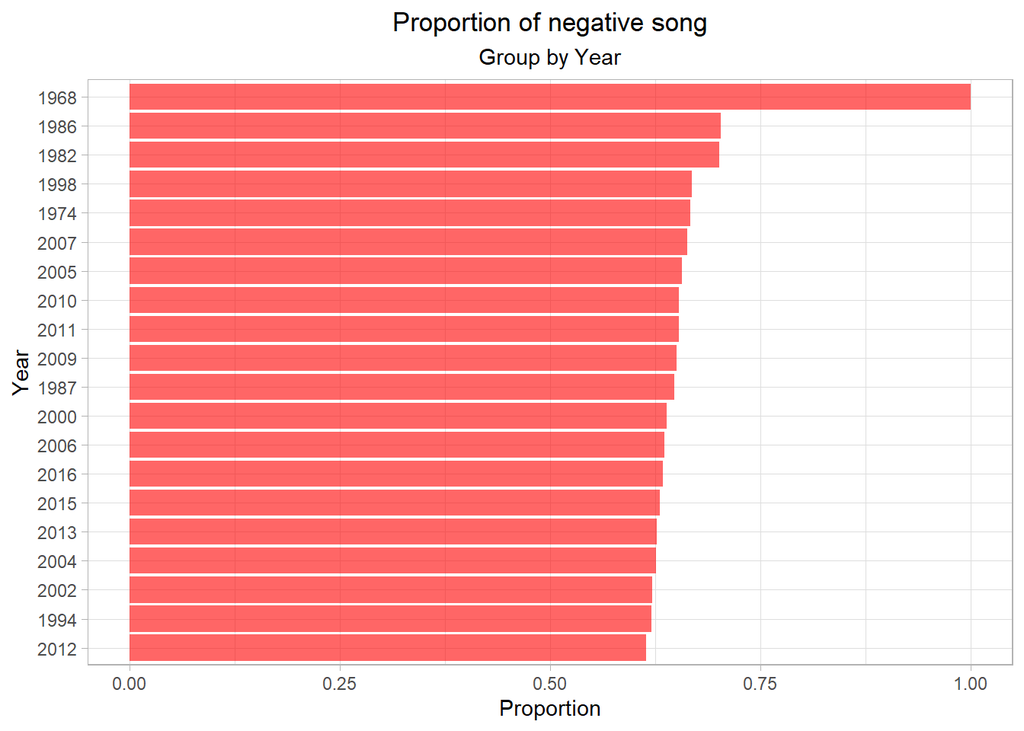

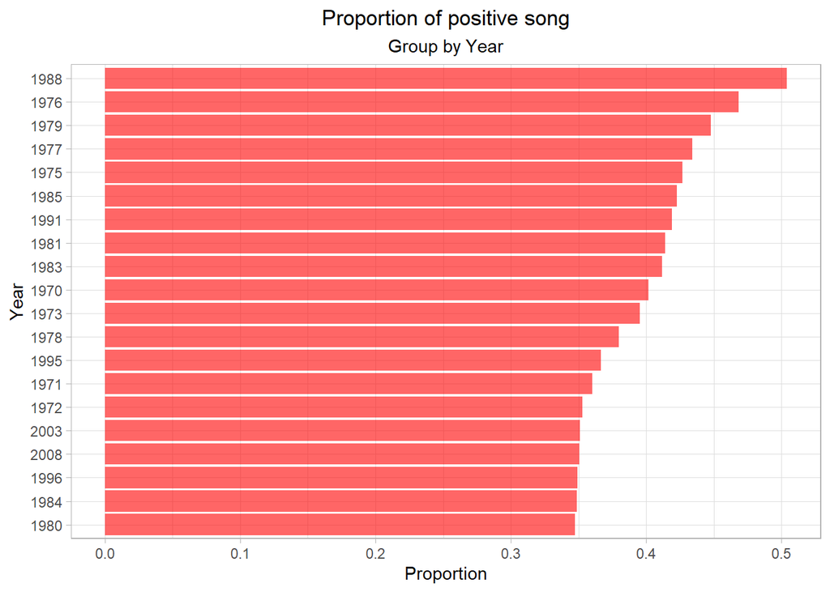

Metal and Hip-hop are the music genres with the most negative words and Jazz is with the least. Columbia, Phillippines and Russia are the regional using positive words while most of others use negative words more. Since there was only one song in 1968, the proportion reached 100%. In addition, the negative words were used the most in 1986 and 1982 and the least used in 1988.

### Question 2 - What kind of music is out of the ordinary?

From the shinyapp and statistical chart above, we can see that most of music uses words like ‘love’ and ‘time’. we will be curious about such a question, what kind of music doesn’t contain the most frequent words. After selecting the music that doesn’t contain the most frequent 15 words, we can get music statistics in different categories as follows.

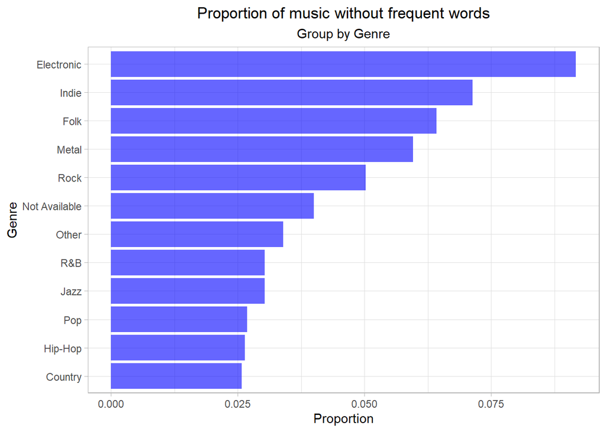

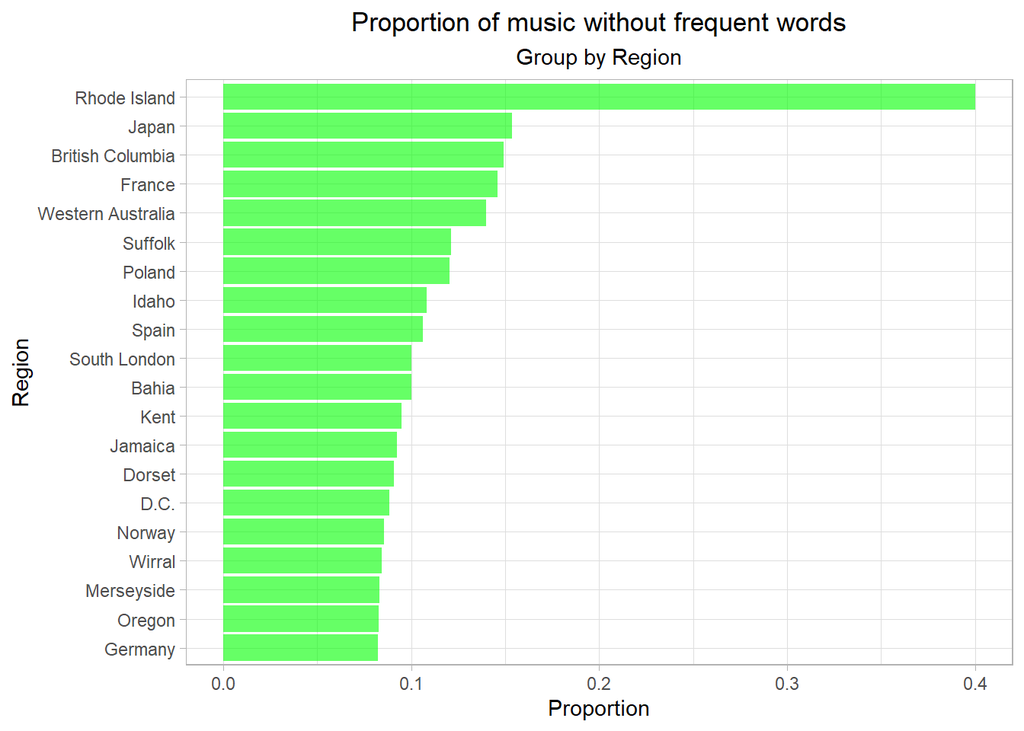

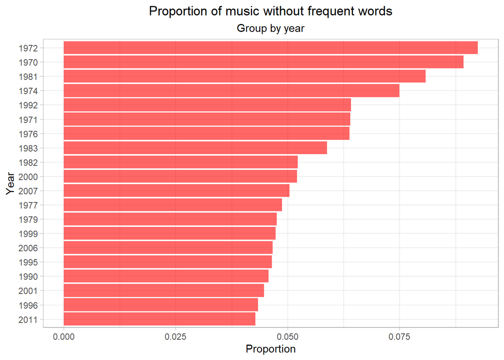

These statisical graphs show that electronic music uses the least high-frequency words when classifying music genres. Rhode Island, Japan, British Columbia, France and Western Australia use the least frequent words when classifying by country and people used the least frequent words in 1972, 1970, 1981 and 1974.Then, what are the musical keywords for these genres, places and times?

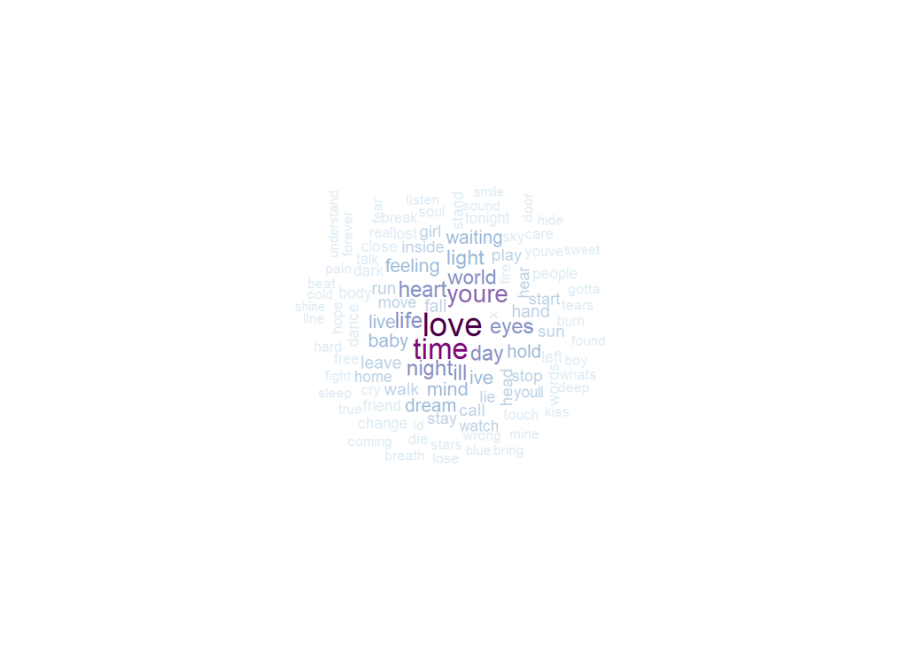

If we don’t remove high-frequency words, taking Electronic genre as an example, then even the most distinctive genre, its main words are still ‘love’ and ‘time’. We can’t see the essence behind lyrics just by categorizing them like this, because the characteristics of these words determine that they are suitable to every music. So in the following analysis, I removed the 15 most frequent words.

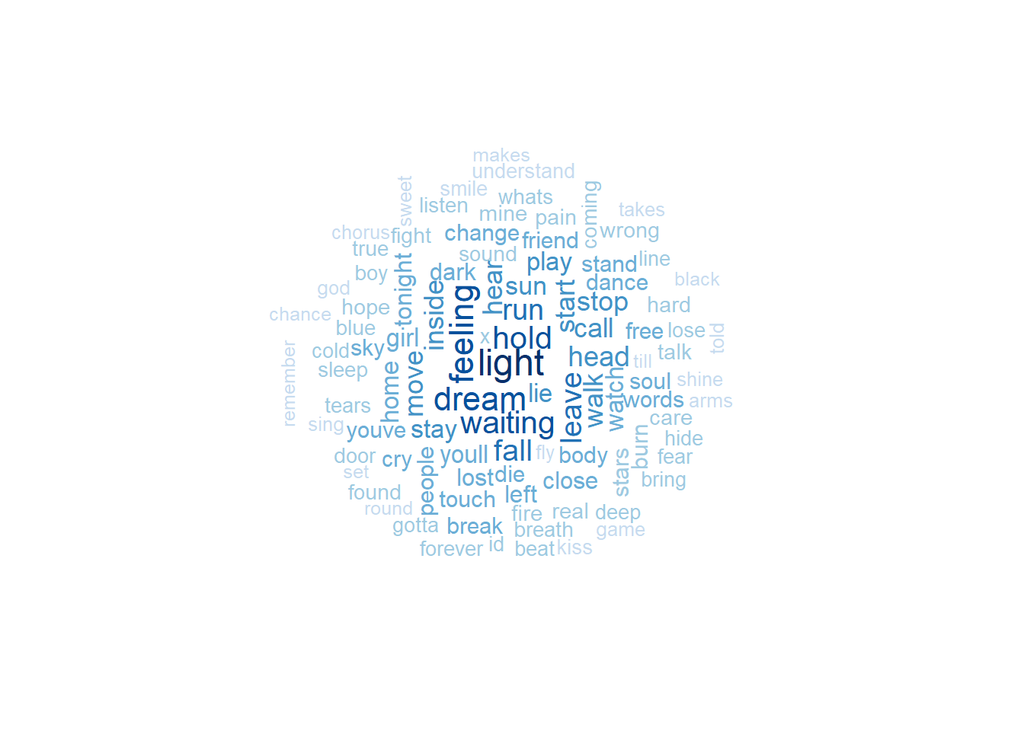

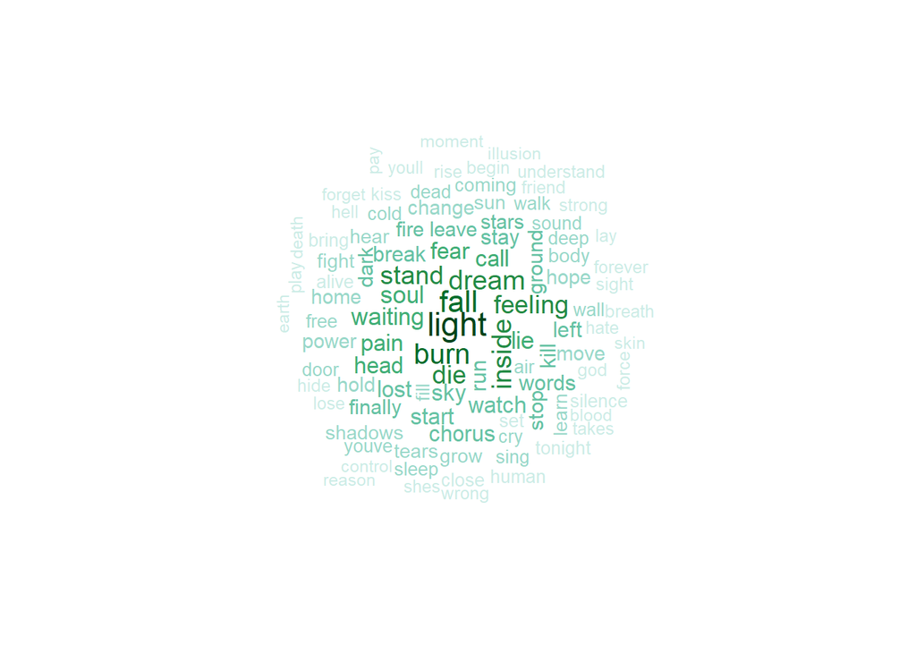

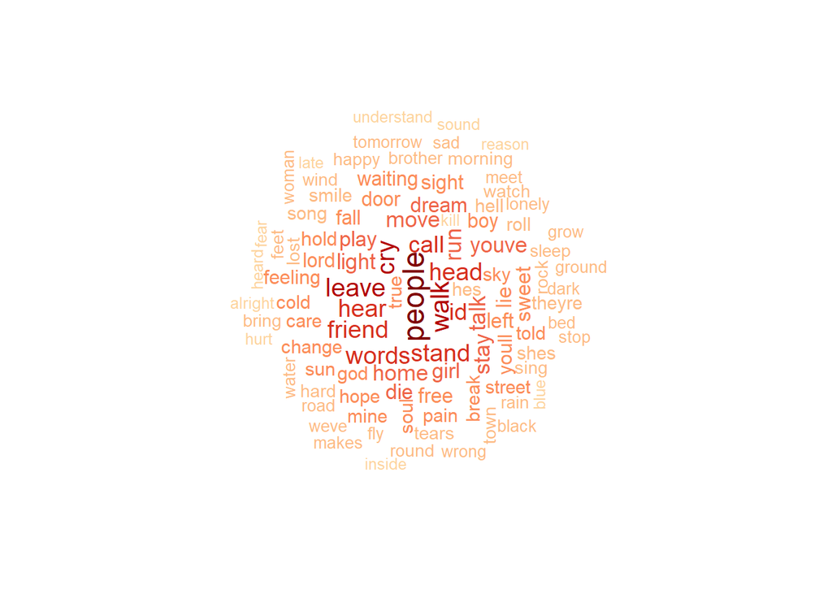

The hue of the graphs above are consistent with the previous graphs. We can see that ‘feeling’, ‘light’, ‘dream’ are more used by Electronic music. These words also match the entertaining nature of this kind of music. ‘burn’, ‘fall’, ‘lost’ are more used in those regions above, many negative words appear in wordcloud. It it related to the instability in these areas. In 1970s, ‘people’, ‘friend’ and ‘stand’ used a lot. It can be seen that this is an age of peaceful development.

Frequent words are related to their characteristics, and they often appear in any lyrics. However, words other than them can better reflect the real thoughts of people in a certain region, era, and character. Statistics on these words can better reflect the story behind the lyrics.